# IMF BUSSINESS SCHOOL

## LMA: Introducción a DataFrames con Python

### Juan Manuel Moreno

Importamos la librería pandas para poder trabajar con DataFrames en Python, en caso de que no venga instalada por defecto podemos realizar lo siguiente:

- `pip install pandas`
- `conda install pandas`
- `conda install -c anaconda pandas`

```python
# Importamos pandas, utilizaremos el alias para denominar a cada función de pandas 'pd'
import pandas as pd
```

## Creación de un DataFrame

### 1.- A través de Series

Tenemos que tener en cuenta que las series funcionan de forma similar a un diccionario de datos donde tenemos los archivos formados por {clave_1: 'valor uno', clave_2. 'valor dos', ....., clave_n: 'valor m'}. Las series pueden formarse a través de un numpy array o una lista y unos valores que actuarán como índices (si no se introducen se tomarán por defecto de 0 a la longitud del conjunto de elementos).

```python
# Ejemplo 1 a través de Series
series_lista = pd.Series([46,41,36,33], index=['FC BARCELONA',
                                   'ATLETICO',
                                   'REAL MADRID',
                                   'SEVILLA'] )

series_lista
```

```
FC BARCELONA    46
ATLETICO        41
REAL MADRID     36
SEVILLA         33
dtype: int64
```

La función principal que nos permite pasar prácticamente cualquier tipo de variable (lista, array, diccionario de datos...) es:

- `__pandas.DataFrame()__`

```python
# Creamos un Dataframe a través del objeto Series
df_series_lista = pd.DataFrame(series_lista)

# Vemos que por defecto, se genera una columna con nombre 0, ya que no se lo hemos especificado.
df_series_lista
```

|  | 0 |
| --- | --- |
| FC BARCELONA | 46 |
| ATLETICO | 41 |
| REAL MADRID | 36 |
| SEVILLA | 33 |

### 2.- A través de Numpy Array

```python
# Ejemplo 2 a través numpy array
import numpy as np

# Creamos un array de 5 número aleatorios
array_uno = np.random.rand(5)

pd.DataFrame(array_uno)
```

|  | 0 |
| --- | --- |
| 0 | 0.559643 |
| 1 | 0.216425 |
| 2 | 0.928248 |
| 3 | 0.088661 |
| 4 | 0.453951 |

### 3.- A través de Listas

```python
# Ejemplo 3 listas

# Creamos una lista
lista = ['a', 'abc',1, 2.0, 450, 'qwerty']

# Pasamos la lista a un DataFrame
df_list = pd.DataFrame(lista)

df_list
```

|  | 0 |
| --- | --- |
| 0 | a |
| 1 | abc |
| 2 | 1 |
| 3 | 2 |
| 4 | 450 |
| 5 | qwerty |

### 4.- A través de un diccionario de datos

```python
# Ejemplo 4 Diccionario de datos

# Creamos un Diccionario de datos
dict_cli = {'ID001': 'Cliente uno',
            'ID002': 'Cliente dos',
            'ID003': 'Cliente tres',
            'ID004': 'Cliente cuatro',
            'ID005': 'Cliente cinco'}

dict_cli
```

```
{'ID001': 'Cliente uno',
 'ID002': 'Cliente dos',
 'ID003': 'Cliente tres',
 'ID004': 'Cliente cuatro',
 'ID005': 'Cliente cinco'}
```

```python
# Pasamos el dict a un DataFrame

df_dict = pd.DataFrame.from_dict(dict_cli, orient='index')

df_dict
```

|  | 0 |
| --- | --- |
| ID001 | Cliente uno |
| ID002 | Cliente dos |
| ID003 | Cliente tres |
| ID004 | Cliente cuatro |
| ID005 | Cliente cinco |

### 5.- Desde un archivo de datos (CSV)

```python
# Ejemplo 5 Archivo de datos - csv
df_iris = pd.read_csv('iris.csv')

df_iris
```

|  | Sepal.Length | Sepal.Width | Petal.Length | Petal.Width | Species |
| --- | --- | --- | --- | --- | --- |
| 0 | 5.1 | 3.5 | 1.4 | 0.2 | setosa |
| 1 | 4.9 | 3.0 | 1.4 | 0.2 | setosa |
| 2 | 4.7 | 3.2 | 1.3 | 0.2 | setosa |
| 3 | 4.6 | 3.1 | 1.5 | 0.2 | setosa |
| 4 | 5.0 | 3.6 | 1.4 | 0.2 | setosa |
| 5 | 5.4 | 3.9 | 1.7 | 0.4 | setosa |
| 6 | 4.6 | 3.4 | 1.4 | 0.3 | setosa |
| 7 | 5.0 | 3.4 | 1.5 | 0.2 | setosa |
| 8 | 4.4 | 2.9 | 1.4 | 0.2 | setosa |
| 9 | 4.9 | 3.1 | 1.5 | 0.1 | setosa |
| 10 | 5.4 | 3.7 | 1.5 | 0.2 | setosa |
| 11 | 4.8 | 3.4 | 1.6 | 0.2 | setosa |
| 12 | 4.8 | 3.0 | 1.4 | 0.1 | setosa |
| 13 | 4.3 | 3.0 | 1.1 | 0.1 | setosa |
| 14 | 5.8 | 4.0 | 1.2 | 0.2 | setosa |
| 15 | 5.7 | 4.4 | 1.5 | 0.4 | setosa |
| 16 | 5.4 | 3.9 | 1.3 | 0.4 | setosa |
| 17 | 5.1 | 3.5 | 1.4 | 0.3 | setosa |
| 18 | 5.7 | 3.8 | 1.7 | 0.3 | setosa |
| 19 | 5.1 | 3.8 | 1.5 | 0.3 | setosa |
| 20 | 5.4 | 3.4 | 1.7 | 0.2 | setosa |
| 21 | 5.1 | 3.7 | 1.5 | 0.4 | setosa |
| 22 | 4.6 | 3.6 | 1.0 | 0.2 | setosa |
| 23 | 5.1 | 3.3 | 1.7 | 0.5 | setosa |
| 24 | 4.8 | 3.4 | 1.9 | 0.2 | setosa |
| 25 | 5.0 | 3.0 | 1.6 | 0.2 | setosa |
| 26 | 5.0 | 3.4 | 1.6 | 0.4 | setosa |
| 27 | 5.2 | 3.5 | 1.5 | 0.2 | setosa |
| 28 | 5.2 | 3.4 | 1.4 | 0.2 | setosa |
| 29 | 4.7 | 3.2 | 1.6 | 0.2 | setosa |
| ... | ... | ... | ... | ... | ... |
| 120 | 6.9 | 3.2 | 5.7 | 2.3 | virginica |
| 121 | 5.6 | 2.8 | 4.9 | 2.0 | virginica |
| 122 | 7.7 | 2.8 | 6.7 | 2.0 | virginica |
| 123 | 6.3 | 2.7 | 4.9 | 1.8 | virginica |
| 124 | 6.7 | 3.3 | 5.7 | 2.1 | virginica |
| 125 | 7.2 | 3.2 | 6.0 | 1.8 | virginica |
| 126 | 6.2 | 2.8 | 4.8 | 1.8 | virginica |
| 127 | 6.1 | 3.0 | 4.9 | 1.8 | virginica |
| 128 | 6.4 | 2.8 | 5.6 | 2.1 | virginica |
| 129 | 7.2 | 3.0 | 5.8 | 1.6 | virginica |
| 130 | 7.4 | 2.8 | 6.1 | 1.9 | virginica |
| 131 | 7.9 | 3.8 | 6.4 | 2.0 | virginica |
| 132 | 6.4 | 2.8 | 5.6 | 2.2 | virginica |
| 133 | 6.3 | 2.8 | 5.1 | 1.5 | virginica |
| 134 | 6.1 | 2.6 | 5.6 | 1.4 | virginica |
| 135 | 7.7 | 3.0 | 6.1 | 2.3 | virginica |
| 136 | 6.3 | 3.4 | 5.6 | 2.4 | virginica |
| 137 | 6.4 | 3.1 | 5.5 | 1.8 | virginica |
| 138 | 6.0 | 3.0 | 4.8 | 1.8 | virginica |
| 139 | 6.9 | 3.1 | 5.4 | 2.1 | virginica |
| 140 | 6.7 | 3.1 | 5.6 | 2.4 | virginica |
| 141 | 6.9 | 3.1 | 5.1 | 2.3 | virginica |
| 142 | 5.8 | 2.7 | 5.1 | 1.9 | virginica |
| 143 | 6.8 | 3.2 | 5.9 | 2.3 | virginica |
| 144 | 6.7 | 3.3 | 5.7 | 2.5 | virginica |
| 145 | 6.7 | 3.0 | 5.2 | 2.3 | virginica |
| 146 | 6.3 | 2.5 | 5.0 | 1.9 | virginica |
| 147 | 6.5 | 3.0 | 5.2 | 2.0 | virginica |
| 148 | 6.2 | 3.4 | 5.4 | 2.3 | virginica |
| 149 | 5.9 | 3.0 | 5.1 | 1.8 | virginica |

150 rows × 5 columns

## Obtener series a través de un dataframe

Como se puede comprobar, si observamos cada columna tomando el índice, veremos que un dataframe en Python es una composición de varias series compartiendo el mismo tipo de índice. De esta forma, podemos seleccionar una sola columna del dataframe y veremos que obtenemos lo mismo que un objeto series.

## Obtención de columnas de un dataframe

Lo primero de todo, veremos cómo seleccionar una columna de un DataFrame

```python
# Únicamente tenemos que escribir entre corchetes el nombre de la columna
df_iris['Sepal.Length']
```

```
0      5.1
1      4.9
2      4.7
3      4.6
4      5.0
5      5.4
6      4.6
7      5.0
8      4.4
9      4.9
10     5.4
11     4.8
12     4.8
13     4.3
14     5.8
```

[output cut: 47 more lines]

Si observamos el tipo de la columna, veremos que es tipo series

```python
print(type(df_iris['Petal.Length']))
```

```
<class 'pandas.core.series.Series'>
```

Otra forma de obtener una única columna. Simplemente realizando: **nombre_data_frame.nombre_columa**

```python
df_iris.Species
```

```
0         setosa
1         setosa
2         setosa
3         setosa
4         setosa
5         setosa
6         setosa
7         setosa
8         setosa
9         setosa
10        setosa
11        setosa
12        setosa
13        setosa
14        setosa
```

[output cut: 47 more lines]

## Selección de multiples columnas

Ahora que ya hemos visto como un DataFrame se compone de Series, podemos ver cómo seleccionar varias columnas. Para ello, simplemente tenemos que encerrar entre corchetes los nombres de las columnas que queremos seleccionar como:

**nombre_df[['columna_uno', 'columna_dos', 'columna_tres']]**

Para realizar lo mismo mediante indexación, es decir, obtener un subconjunto de columnas del dataframe por la posición que ocupan las columnas podemos hacer:

- **nombre_dataframe[nombre_dataframe.columns[[col_n, col_m]]]**
- **nombre_dataframe.iloc[:, [col_n, col_m]]**

```python
df_iris[['Species', 'Sepal.Width']]
```

|  | Species | Sepal.Width |
| --- | --- | --- |
| 0 | setosa | 3.5 |
| 1 | setosa | 3.0 |
| 2 | setosa | 3.2 |
| 3 | setosa | 3.1 |
| 4 | setosa | 3.6 |
| 5 | setosa | 3.9 |
| 6 | setosa | 3.4 |
| 7 | setosa | 3.4 |
| 8 | setosa | 2.9 |
| 9 | setosa | 3.1 |
| 10 | setosa | 3.7 |
| 11 | setosa | 3.4 |
| 12 | setosa | 3.0 |
| 13 | setosa | 3.0 |
| 14 | setosa | 4.0 |
| 15 | setosa | 4.4 |
| 16 | setosa | 3.9 |
| 17 | setosa | 3.5 |
| 18 | setosa | 3.8 |
| 19 | setosa | 3.8 |
| 20 | setosa | 3.4 |
| 21 | setosa | 3.7 |
| 22 | setosa | 3.6 |
| 23 | setosa | 3.3 |
| 24 | setosa | 3.4 |
| 25 | setosa | 3.0 |
| 26 | setosa | 3.4 |
| 27 | setosa | 3.5 |
| 28 | setosa | 3.4 |
| 29 | setosa | 3.2 |
| ... | ... | ... |
| 120 | virginica | 3.2 |
| 121 | virginica | 2.8 |
| 122 | virginica | 2.8 |
| 123 | virginica | 2.7 |
| 124 | virginica | 3.3 |
| 125 | virginica | 3.2 |
| 126 | virginica | 2.8 |
| 127 | virginica | 3.0 |
| 128 | virginica | 2.8 |
| 129 | virginica | 3.0 |
| 130 | virginica | 2.8 |
| 131 | virginica | 3.8 |
| 132 | virginica | 2.8 |
| 133 | virginica | 2.8 |
| 134 | virginica | 2.6 |
| 135 | virginica | 3.0 |
| 136 | virginica | 3.4 |
| 137 | virginica | 3.1 |
| 138 | virginica | 3.0 |
| 139 | virginica | 3.1 |
| 140 | virginica | 3.1 |
| 141 | virginica | 3.1 |
| 142 | virginica | 2.7 |
| 143 | virginica | 3.2 |
| 144 | virginica | 3.3 |
| 145 | virginica | 3.0 |
| 146 | virginica | 2.5 |
| 147 | virginica | 3.0 |
| 148 | virginica | 3.4 |
| 149 | virginica | 3.0 |

150 rows × 2 columns

```python
df_iris.columns[1]
```

```
'Sepal.Width'
```

```python
# Mediante la posición de las columnas
df_iris[df_iris.columns[[1,3]]]
```

|  | Sepal.Width | Petal.Width |
| --- | --- | --- |
| 0 | 3.5 | 0.2 |
| 1 | 3.0 | 0.2 |
| 2 | 3.2 | 0.2 |
| 3 | 3.1 | 0.2 |
| 4 | 3.6 | 0.2 |
| 5 | 3.9 | 0.4 |
| 6 | 3.4 | 0.3 |
| 7 | 3.4 | 0.2 |
| 8 | 2.9 | 0.2 |
| 9 | 3.1 | 0.1 |
| 10 | 3.7 | 0.2 |
| 11 | 3.4 | 0.2 |
| 12 | 3.0 | 0.1 |
| 13 | 3.0 | 0.1 |
| 14 | 4.0 | 0.2 |
| 15 | 4.4 | 0.4 |
| 16 | 3.9 | 0.4 |
| 17 | 3.5 | 0.3 |
| 18 | 3.8 | 0.3 |
| 19 | 3.8 | 0.3 |
| 20 | 3.4 | 0.2 |
| 21 | 3.7 | 0.4 |
| 22 | 3.6 | 0.2 |
| 23 | 3.3 | 0.5 |
| 24 | 3.4 | 0.2 |
| 25 | 3.0 | 0.2 |
| 26 | 3.4 | 0.4 |
| 27 | 3.5 | 0.2 |
| 28 | 3.4 | 0.2 |
| 29 | 3.2 | 0.2 |
| ... | ... | ... |
| 120 | 3.2 | 2.3 |
| 121 | 2.8 | 2.0 |
| 122 | 2.8 | 2.0 |
| 123 | 2.7 | 1.8 |
| 124 | 3.3 | 2.1 |
| 125 | 3.2 | 1.8 |
| 126 | 2.8 | 1.8 |
| 127 | 3.0 | 1.8 |
| 128 | 2.8 | 2.1 |
| 129 | 3.0 | 1.6 |
| 130 | 2.8 | 1.9 |
| 131 | 3.8 | 2.0 |
| 132 | 2.8 | 2.2 |
| 133 | 2.8 | 1.5 |
| 134 | 2.6 | 1.4 |
| 135 | 3.0 | 2.3 |
| 136 | 3.4 | 2.4 |
| 137 | 3.1 | 1.8 |
| 138 | 3.0 | 1.8 |
| 139 | 3.1 | 2.1 |
| 140 | 3.1 | 2.4 |
| 141 | 3.1 | 2.3 |
| 142 | 2.7 | 1.9 |
| 143 | 3.2 | 2.3 |
| 144 | 3.3 | 2.5 |
| 145 | 3.0 | 2.3 |
| 146 | 2.5 | 1.9 |
| 147 | 3.0 | 2.0 |
| 148 | 3.4 | 2.3 |
| 149 | 3.0 | 1.8 |

150 rows × 2 columns

```python
# df_iris.iloc[filas : columnas] - Python
# df_iris[filas, columnas] - R
```

```python
df_iris.iloc[:,[1,3]]
```

|  | Sepal.Width | Petal.Width |
| --- | --- | --- |
| 0 | 3.5 | 0.2 |
| 1 | 3.0 | 0.2 |
| 2 | 3.2 | 0.2 |
| 3 | 3.1 | 0.2 |
| 4 | 3.6 | 0.2 |
| 5 | 3.9 | 0.4 |
| 6 | 3.4 | 0.3 |
| 7 | 3.4 | 0.2 |
| 8 | 2.9 | 0.2 |
| 9 | 3.1 | 0.1 |
| 10 | 3.7 | 0.2 |
| 11 | 3.4 | 0.2 |
| 12 | 3.0 | 0.1 |
| 13 | 3.0 | 0.1 |
| 14 | 4.0 | 0.2 |
| 15 | 4.4 | 0.4 |
| 16 | 3.9 | 0.4 |
| 17 | 3.5 | 0.3 |
| 18 | 3.8 | 0.3 |
| 19 | 3.8 | 0.3 |
| 20 | 3.4 | 0.2 |
| 21 | 3.7 | 0.4 |
| 22 | 3.6 | 0.2 |
| 23 | 3.3 | 0.5 |
| 24 | 3.4 | 0.2 |
| 25 | 3.0 | 0.2 |
| 26 | 3.4 | 0.4 |
| 27 | 3.5 | 0.2 |
| 28 | 3.4 | 0.2 |
| 29 | 3.2 | 0.2 |
| ... | ... | ... |
| 120 | 3.2 | 2.3 |
| 121 | 2.8 | 2.0 |
| 122 | 2.8 | 2.0 |
| 123 | 2.7 | 1.8 |
| 124 | 3.3 | 2.1 |
| 125 | 3.2 | 1.8 |
| 126 | 2.8 | 1.8 |
| 127 | 3.0 | 1.8 |
| 128 | 2.8 | 2.1 |
| 129 | 3.0 | 1.6 |
| 130 | 2.8 | 1.9 |
| 131 | 3.8 | 2.0 |
| 132 | 2.8 | 2.2 |
| 133 | 2.8 | 1.5 |
| 134 | 2.6 | 1.4 |
| 135 | 3.0 | 2.3 |
| 136 | 3.4 | 2.4 |
| 137 | 3.1 | 1.8 |
| 138 | 3.0 | 1.8 |
| 139 | 3.1 | 2.1 |
| 140 | 3.1 | 2.4 |
| 141 | 3.1 | 2.3 |
| 142 | 2.7 | 1.9 |
| 143 | 3.2 | 2.3 |
| 144 | 3.3 | 2.5 |
| 145 | 3.0 | 2.3 |
| 146 | 2.5 | 1.9 |
| 147 | 3.0 | 2.0 |
| 148 | 3.4 | 2.3 |
| 149 | 3.0 | 1.8 |

150 rows × 2 columns

## Obtener multiples filas de un dataframe

Por lo general, podemos utilizar las mismas propiedades que las de las listas, salvo seleccionar una única fila que es diferente:

- Para seleccionar desde la primera fila hasta un límite realizamos: `__dataframe[0:n]__`, análogamente podemos omitir el cero y realizar simplemente: `__dataframe[ :n]__`
- Para seleccionar desde una fila hasta el final realizamos: `__dataframe[n:]__`
- Para seleccionar un rango definido de filas realizamos: `__dataframe[n:m]__`

```python
# Seleccionamos de la fila 0 a la 3
df_iris[0:3]
```

|  | Sepal.Length | Sepal.Width | Petal.Length | Petal.Width | Species |
| --- | --- | --- | --- | --- | --- |
| 0 | 5.1 | 3.5 | 1.4 | 0.2 | setosa |
| 1 | 4.9 | 3.0 | 1.4 | 0.2 | setosa |
| 2 | 4.7 | 3.2 | 1.3 | 0.2 | setosa |

```python
# Vemos que es lo mismo si quitamos el cero
df_iris[ :3]
```

|  | Sepal.Length | Sepal.Width | Petal.Length | Petal.Width | Species |
| --- | --- | --- | --- | --- | --- |
| 0 | 5.1 | 3.5 | 1.4 | 0.2 | setosa |
| 1 | 4.9 | 3.0 | 1.4 | 0.2 | setosa |
| 2 | 4.7 | 3.2 | 1.3 | 0.2 | setosa |

```python
# Seleccionamos de la fila 147 al final del dataframe
df_iris[147: ]
```

|  | Sepal.Length | Sepal.Width | Petal.Length | Petal.Width | Species |
| --- | --- | --- | --- | --- | --- |
| 147 | 6.5 | 3.0 | 5.2 | 2.0 | virginica |
| 148 | 6.2 | 3.4 | 5.4 | 2.3 | virginica |
| 149 | 5.9 | 3.0 | 5.1 | 1.8 | virginica |

```python
# Obtenemos un rango personalizado de 10 posiciones.
df_iris[10:20]
```

|  | Sepal.Length | Sepal.Width | Petal.Length | Petal.Width | Species |
| --- | --- | --- | --- | --- | --- |
| 10 | 5.4 | 3.7 | 1.5 | 0.2 | setosa |
| 11 | 4.8 | 3.4 | 1.6 | 0.2 | setosa |
| 12 | 4.8 | 3.0 | 1.4 | 0.1 | setosa |
| 13 | 4.3 | 3.0 | 1.1 | 0.1 | setosa |
| 14 | 5.8 | 4.0 | 1.2 | 0.2 | setosa |
| 15 | 5.7 | 4.4 | 1.5 | 0.4 | setosa |
| 16 | 5.4 | 3.9 | 1.3 | 0.4 | setosa |
| 17 | 5.1 | 3.5 | 1.4 | 0.3 | setosa |
| 18 | 5.7 | 3.8 | 1.7 | 0.3 | setosa |
| 19 | 5.1 | 3.8 | 1.5 | 0.3 | setosa |

Para seleccionar una sola fila no podemos hacer como con las listas, indexar una única posición `lista[n]`, ya que esto no nos devuelve nada, para ello, tenemos que seleccionar como un rango personalizado la fila que queremos mostrar más una posición `dataframe[n:n+1]`

```python
# Esto no devuelve nada, solo el nombre de las columnas
df_iris[3:3]
```

|  | Sepal.Length | Sepal.Width | Petal.Length | Petal.Width | Species |
| --- | --- | --- | --- | --- | --- |

```python
# Observamos la fila 4
df_iris[3:4]
```

|  | Sepal.Length | Sepal.Width | Petal.Length | Petal.Width | Species |
| --- | --- | --- | --- | --- | --- |
| 3 | 4.6 | 3.1 | 1.5 | 0.2 | setosa |

## Resumen función iloc

Con la función **.iloc** podemos seleccionar varias filas de una forma muy sencilla que puede resumirse como:

- `dataframe.iloc[0]` - Primera fila de un dataframe.
- `dataframe.iloc[1]` - Segunda fila de un dataframe.
- `dataframe.iloc[-1]` - Última fila de un dataframe
- `dataframe.iloc[[n]]` - Fila *n* del dataframe.
- `dataframe.iloc[n:m]` - Rango personalizado de las filas *n* a *m*

En columnas el resumen de la función **.iloc** pasaría a ser:

Podemos también realizar una selección múltiple de columnas filas con **.iloc** con los siguientes ejemplos:

- `dataframe.iloc[[0,5,7,9], [1,4]]` - Selección de las filas 0,5,7,9 de las columnas 1 y 4
- `dataframe.iloc[0:10, 0:2]` - Selección basada en rangos de las filas 0 a 10 de las columnas 0 a 2

```python
df_iris.iloc[[1,8,45], [0,3]]
```

|  | Sepal.Length | Petal.Width |
| --- | --- | --- |
| 1 | 4.9 | 0.2 |
| 8 | 4.4 | 0.2 |
| 45 | 4.8 | 0.3 |

```python
df_iris.iloc[0:10, 0:3]
```

|  | Sepal.Length | Sepal.Width | Petal.Length |
| --- | --- | --- | --- |
| 0 | 5.1 | 3.5 | 1.4 |
| 1 | 4.9 | 3.0 | 1.4 |
| 2 | 4.7 | 3.2 | 1.3 |
| 3 | 4.6 | 3.1 | 1.5 |
| 4 | 5.0 | 3.6 | 1.4 |
| 5 | 5.4 | 3.9 | 1.7 |
| 6 | 4.6 | 3.4 | 1.4 |
| 7 | 5.0 | 3.4 | 1.5 |
| 8 | 4.4 | 2.9 | 1.4 |
| 9 | 4.9 | 3.1 | 1.5 |

## Índices de un DataFrame

Se tratan de las posiciones que ocupa cada fila dentro de un dataframe, a no ser que se especifique un tipo de índice concreto basado en etiquetas, los índices serán de 0 a la longitud total del dataframe

```python
# Creamos un dataframe
sales = {
   'region': ["Europe", "Europe", "Europe",
              "USA", "USA", "USA", "LATAM", "LATAM"],
   'volume':[100, 120, 140, 200, 190, 180, 80, 90],
   'year':[2011, 2012, 2013, 2011, 2012, 2013, 2012, 2013]
}
data = pd.DataFrame(sales)
data
```

|  | region | volume | year |
| --- | --- | --- | --- |
| 0 | Europe | 100 | 2011 |
| 1 | Europe | 120 | 2012 |
| 2 | Europe | 140 | 2013 |
| 3 | USA | 200 | 2011 |
| 4 | USA | 190 | 2012 |
| 5 | USA | 180 | 2013 |
| 6 | LATAM | 80 | 2012 |
| 7 | LATAM | 90 | 2013 |

```python
# Observamos el índice con index()
data.index
```

```
RangeIndex(start=0, stop=8, step=1)
```

Dependiendo de cómo estén formados nuestros datos, vamos a poder crear multi índices basados en columnas propias de nuestro dataframe, si nos fijamos la columna region y year tienen elementos repetidos.

Con la función `set_index()` vamos a poder establecer un nuevo índice

```python
region_year = data.set_index(["region", "year"])
region_year
```

| region | year | volume |
| --- | --- | --- |
| Europe | 2011 | 100 |
|  | 2012 | 120 |
|  | 2013 | 140 |
| USA | 2011 | 200 |
|  | 2012 | 190 |
|  | 2013 | 180 |
| LATAM | 2012 | 80 |
|  | 2013 | 90 |

En vista del nuevo dataframe, podemos ver que ahora las columnas region y year actúan como índice, por lo que si consultamos la primera fila...

```python
region_year.iloc[0]
```

```
volume    100
Name: (Europe, 2011), dtype: int64
```

Obtenemos que pertenece a la volume, siendo region (Europe) y year (2011) sus índices

Del mismo modo, podemos pasar una lista como índice a un dataframe. Obviamente, esta lista debe ser de la misma longitud que el dataframe.

```python
indice = ['FILA_1', 'FILA_2', 'FILA_3', 'FILA_4', 'FILA_5',
          'FILA_6', 'FILA_7', 'FILA_8']

data.index = indice

data
```

|  | region | volume | year |
| --- | --- | --- | --- |
| FILA_1 | Europe | 100 | 2011 |
| FILA_2 | Europe | 120 | 2012 |
| FILA_3 | Europe | 140 | 2013 |
| FILA_4 | USA | 200 | 2011 |
| FILA_5 | USA | 190 | 2012 |
| FILA_6 | USA | 180 | 2013 |
| FILA_7 | LATAM | 80 | 2012 |
| FILA_8 | LATAM | 90 | 2013 |

Con la función `.loc` podemos buscar elementos en el índice

```python
data.loc['FILA_7']
```

```
region    LATAM
volume       80
year       2012
Name: FILA_7, dtype: object
```

## Algunas funciones básicas de un dataframe

A continuación vamos a ver un listado de algunas de las principales funciones que podemos aplicar en un dataframe para operar en sus columnas:

- Obtener las primeras filas de un dataframe con **`.head`**
- Obtener las últimas filas de un dataframe con **`.tail`**
- Obtener los elmentos únicos de una columna de un dataframe con **`.unique`**
- Obtener un resumen estadístico del dataset con **`.describe`**
- Obtener la media de una columna con **`.mean`**
- Obtener una copia de un dataframe con **`.copy`**
- Ver los nombres de las columnas de un dataframe con **`.columns`**
- Obtener la correlación entre todas las variables numéricas con **`.corr`**
- Borrar duplicados de un dataframe con **`.drop_duplicates`**
- Especialmente para Big Data sets podemos ver el consumo en memoria RAM de nuestro dataset con **`.memory_usage`**
- Ver un resumen resumen gráfico (basado en densidad, scatter plots y gráficas de correlaciones) de todas las variables del dataframe con **`.scatter_matrix`**
- Obtener un histograma de cada variable numérica del dataset con **`.hist`**

### Primeras filas de un Dataframe

```python
# Primeras filas del dataframe
df_iris.head()
```

|  | Sepal.Length | Sepal.Width | Petal.Length | Petal.Width | Species |
| --- | --- | --- | --- | --- | --- |
| 0 | 5.1 | 3.5 | 1.4 | 0.2 | setosa |
| 1 | 4.9 | 3.0 | 1.4 | 0.2 | setosa |
| 2 | 4.7 | 3.2 | 1.3 | 0.2 | setosa |
| 3 | 4.6 | 3.1 | 1.5 | 0.2 | setosa |
| 4 | 5.0 | 3.6 | 1.4 | 0.2 | setosa |

Si en .head() no especificamos nada, por defecto, se muestran 5, podemos especificar el número de filas a mostrar.

```python
df_iris.head(10)
```

|  | Sepal.Length | Sepal.Width | Petal.Length | Petal.Width | Species |
| --- | --- | --- | --- | --- | --- |
| 0 | 5.1 | 3.5 | 1.4 | 0.2 | setosa |
| 1 | 4.9 | 3.0 | 1.4 | 0.2 | setosa |
| 2 | 4.7 | 3.2 | 1.3 | 0.2 | setosa |
| 3 | 4.6 | 3.1 | 1.5 | 0.2 | setosa |
| 4 | 5.0 | 3.6 | 1.4 | 0.2 | setosa |
| 5 | 5.4 | 3.9 | 1.7 | 0.4 | setosa |
| 6 | 4.6 | 3.4 | 1.4 | 0.3 | setosa |
| 7 | 5.0 | 3.4 | 1.5 | 0.2 | setosa |
| 8 | 4.4 | 2.9 | 1.4 | 0.2 | setosa |
| 9 | 4.9 | 3.1 | 1.5 | 0.1 | setosa |

### Últimas filas de un Dataframe

Lo mismo pasa con el comando **tail**

```python
df_iris.tail()
```

|  | Sepal.Length | Sepal.Width | Petal.Length | Petal.Width | Species |
| --- | --- | --- | --- | --- | --- |
| 145 | 6.7 | 3.0 | 5.2 | 2.3 | virginica |
| 146 | 6.3 | 2.5 | 5.0 | 1.9 | virginica |
| 147 | 6.5 | 3.0 | 5.2 | 2.0 | virginica |
| 148 | 6.2 | 3.4 | 5.4 | 2.3 | virginica |
| 149 | 5.9 | 3.0 | 5.1 | 1.8 | virginica |

```python
df_iris.tail(2)
```

|  | Sepal.Length | Sepal.Width | Petal.Length | Petal.Width | Species |
| --- | --- | --- | --- | --- | --- |
| 148 | 6.2 | 3.4 | 5.4 | 2.3 | virginica |
| 149 | 5.9 | 3.0 | 5.1 | 1.8 | virginica |

### Valores únicos por columna

```python
# Observamos los valores únicos de la columna Species
df_iris['Species'].unique()
```

```
array(['setosa', 'versicolor', 'virginica'], dtype=object)
```

```python
# Valores únicos de la columna Petal.Width
df_iris['Petal.Width'].unique()
```

```
array([0.2, 0.4, 0.3, 0.1, 0.5, 0.6, 1.4, 1.5, 1.3, 1.6, 1. , 1.1, 1.8,
       1.2, 1.7, 2.5, 1.9, 2.1, 2.2, 2. , 2.4, 2.3])
```

### Resumen estadístico

```python
# Resumen estadístico.
df_iris.describe()
```

|  | Sepal.Length | Sepal.Width | Petal.Length | Petal.Width |
| --- | --- | --- | --- | --- |
| count | 150.000000 | 150.000000 | 150.000000 | 150.000000 |
| mean | 5.843333 | 3.057333 | 3.758000 | 1.199333 |
| std | 0.828066 | 0.435866 | 1.765298 | 0.762238 |
| min | 4.300000 | 2.000000 | 1.000000 | 0.100000 |
| 25% | 5.100000 | 2.800000 | 1.600000 | 0.300000 |
| 50% | 5.800000 | 3.000000 | 4.350000 | 1.300000 |
| 75% | 6.400000 | 3.300000 | 5.100000 | 1.800000 |
| max | 7.900000 | 4.400000 | 6.900000 | 2.500000 |

### Media de una columna

```python
print('Media de la variable Sepal.Length', round(df_iris['Sepal.Length'].mean(), 3))
print('Media de la variable Petal.Length', round(df_iris['Petal.Length'].mean(), 3))
```

```
Media de la variable Sepal.Length 5.843
Media de la variable Petal.Length 3.758
```

### ¡¡ Mucho cuidado al hacer la copia de un dataframe !!

Es fácil equivocarnos y asignar a una nueva variable un dataframe completo, posteriormente, en esta nueva variable realizar modificaciones, pensando que sólamente las estamos realizando en la copia del dataframe, pero no es así, estamos realizando modificaciones en ambos dataframes ya al estar almacenados en memoria, comparten las mismas posiciones, veamos un ejemplo de como NO copiar un dataframe.

```python
copia_mala = df_iris

# Sustituimos la primera fila de la copia del dataframe por un array de unos.
copia_mala.iloc[[0]] = np.ones(5)
```

```python
copia_mala.head(2)
```

|  | Sepal.Length | Sepal.Width | Petal.Length | Petal.Width | Species |
| --- | --- | --- | --- | --- | --- |
| 0 | 1.0 | 1.0 | 1.0 | 1.0 | 1 |
| 1 | 4.9 | 3.0 | 1.4 | 0.2 | setosa |

Observamos que los cambios se reflejan en el dataframe original

```python
df_iris.head(2)
```

|  | Sepal.Length | Sepal.Width | Petal.Length | Petal.Width | Species |
| --- | --- | --- | --- | --- | --- |
| 0 | 1.0 | 1.0 | 1.0 | 1.0 | 1 |
| 1 | 4.9 | 3.0 | 1.4 | 0.2 | setosa |

Por lo tanto, hemos modificado ambos dataframes, para únicamente realizar modificaciones sobre la copia, hemos de hacer uso del comando `.copy`

```python
df_iris = pd.read_csv('iris.csv')

# Copiamos correctamente el dataframe
df_copia = df_iris.copy()
```

```python
df_copia.iloc[[0]] = np.ones(5)
```

```python
df_copia.head(2)
```

|  | Sepal.Length | Sepal.Width | Petal.Length | Petal.Width | Species |
| --- | --- | --- | --- | --- | --- |
| 0 | 1.0 | 1.0 | 1.0 | 1.0 | 1 |
| 1 | 4.9 | 3.0 | 1.4 | 0.2 | setosa |

```python
df_iris.head(2)
```

|  | Sepal.Length | Sepal.Width | Petal.Length | Petal.Width | Species |
| --- | --- | --- | --- | --- | --- |
| 0 | 5.1 | 3.5 | 1.4 | 0.2 | setosa |
| 1 | 4.9 | 3.0 | 1.4 | 0.2 | setosa |

### Correlaciones de las variables numéricas

```python
df_iris.corr()
```

|  | Sepal.Length | Sepal.Width | Petal.Length | Petal.Width |
| --- | --- | --- | --- | --- |
| Sepal.Length | 1.000000 | -0.117570 | 0.871754 | 0.817941 |
| Sepal.Width | -0.117570 | 1.000000 | -0.428440 | -0.366126 |
| Petal.Length | 0.871754 | -0.428440 | 1.000000 | 0.962865 |
| Petal.Width | 0.817941 | -0.366126 | 0.962865 | 1.000000 |

### Nombres de las columnas de un dataframe

```python
df_iris.columns
```

```
Index(['Sepal.Length', 'Sepal.Width', 'Petal.Length', 'Petal.Width',
       'Species'],
      dtype='object')
```

```python
df_iris.columns[3]
```

```
'Petal.Width'
```

### Borrar duplicados de un dataframe

```python
# Para verlo más claro, vamos a realizar una copia de las diez primeras posiciones del data frame
first_rows = df_iris.head(10).copy()
```

```python
# Duplicamos la fila 9
first_rows = first_rows.append(first_rows.iloc[[9]])
first_rows = first_rows.append(first_rows.iloc[[9]])
```

```python
first_rows
```

|  | Sepal.Length | Sepal.Width | Petal.Length | Petal.Width | Species |
| --- | --- | --- | --- | --- | --- |
| 0 | 5.1 | 3.5 | 1.4 | 0.2 | setosa |
| 1 | 4.9 | 3.0 | 1.4 | 0.2 | setosa |
| 2 | 4.7 | 3.2 | 1.3 | 0.2 | setosa |
| 3 | 4.6 | 3.1 | 1.5 | 0.2 | setosa |
| 4 | 5.0 | 3.6 | 1.4 | 0.2 | setosa |
| 5 | 5.4 | 3.9 | 1.7 | 0.4 | setosa |
| 6 | 4.6 | 3.4 | 1.4 | 0.3 | setosa |
| 7 | 5.0 | 3.4 | 1.5 | 0.2 | setosa |
| 8 | 4.4 | 2.9 | 1.4 | 0.2 | setosa |
| 9 | 4.9 | 3.1 | 1.5 | 0.1 | setosa |
| 9 | 4.9 | 3.1 | 1.5 | 0.1 | setosa |
| 9 | 4.9 | 3.1 | 1.5 | 0.1 | setosa |

```python
first_rows = first_rows.drop_duplicates(subset = ['Sepal.Length'], inplace = False, keep = 'first')
first_rows
```

|  | Sepal.Length | Sepal.Width | Petal.Length | Petal.Width | Species |
| --- | --- | --- | --- | --- | --- |
| 0 | 5.1 | 3.5 | 1.4 | 0.2 | setosa |
| 1 | 4.9 | 3.0 | 1.4 | 0.2 | setosa |
| 2 | 4.7 | 3.2 | 1.3 | 0.2 | setosa |
| 3 | 4.6 | 3.1 | 1.5 | 0.2 | setosa |
| 4 | 5.0 | 3.6 | 1.4 | 0.2 | setosa |
| 5 | 5.4 | 3.9 | 1.7 | 0.4 | setosa |
| 8 | 4.4 | 2.9 | 1.4 | 0.2 | setosa |

### Uso de RAM para un dataframe

```python
# Consumo RAM del dataframe en BYTES
df_iris.memory_usage()
```

```
Index             80
Sepal.Length    1200
Sepal.Width     1200
Petal.Length    1200
Petal.Width     1200
Species         1200
dtype: int64
```

### Análisis gráfico con scatter matrix

```
Using matplotlib backend: Qt5Agg
```

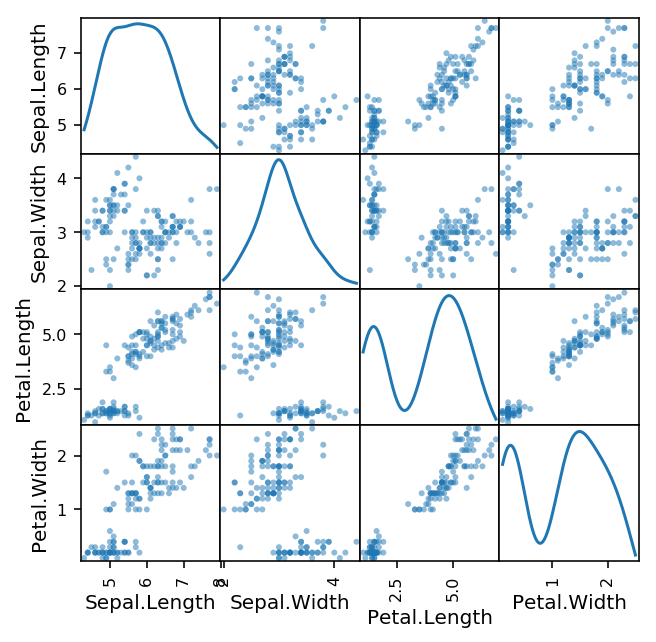

```python
# Configuración para mostrar gráficas en notebook
%pylab
%matplotlib inline
%config InlineBackend.figure_format = 'retina'

# Importamos scatter_matrix
from pandas.plotting import scatter_matrix

# Es necesario que configuremos el tamaño de las gráficas que será el mismo que el número de columnas
scatter_matrix(df_iris, figsize = (len(df_iris.columns), len(df_iris.columns)), diagonal = 'kde');
```

### Histogramas de las variables numéricas

[output not shown]

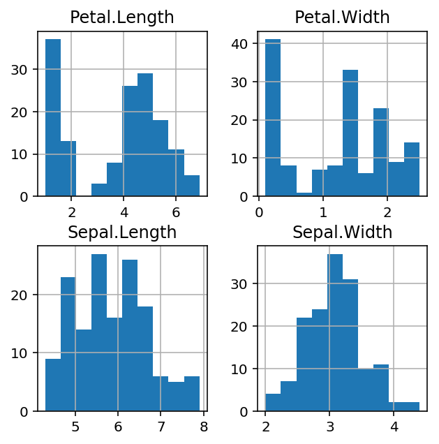

```python
# Histogramas de cada variable continua del dataframe.
df_iris.hist(figsize = (len(df_iris.columns), len(df_iris.columns)))
```

## GROUP BY

Al igual que en SQL, desde Python también podemos realizar agrupaciones de nuestros datos con la función **`groupby`**

```python
# Agrupamos por la media de los valores numéricos para la columna Species
df_iris.groupby(['Species']).mean()
```

| Species | Sepal.Length | Sepal.Width | Petal.Length | Petal.Width |
| --- | --- | --- | --- | --- |
| setosa | 5.006 | 3.428 | 1.462 | 0.246 |
| versicolor | 5.936 | 2.770 | 4.260 | 1.326 |
| virginica | 6.588 | 2.974 | 5.552 | 2.026 |

```python
# Observamos cuántos tipos de flor hay en función de la longitud tanto del
#  pétalo como del sépalo
df_iris.groupby(['Sepal.Length', 'Petal.Length', 'Species']).count()
```

| Sepal.Length | Petal.Length | Species | Sepal.Width | Petal.Width |
| --- | --- | --- | --- | --- |
| 4.3 | 1.1 | setosa | 1 | 1 |
| 4.4 | 1.3 | setosa | 2 | 2 |
|  | 1.4 | setosa | 1 | 1 |
| 4.5 | 1.3 | setosa | 1 | 1 |
| 4.6 | 1.0 | setosa | 1 | 1 |
|  | 1.4 | setosa | 2 | 2 |
|  | 1.5 | setosa | 1 | 1 |
| 4.7 | 1.3 | setosa | 1 | 1 |
|  | 1.6 | setosa | 1 | 1 |
| 4.8 | 1.4 | setosa | 2 | 2 |
|  | 1.6 | setosa | 2 | 2 |
|  | 1.9 | setosa | 1 | 1 |
| 4.9 | 1.4 | setosa | 2 | 2 |
|  | 1.5 | setosa | 2 | 2 |
|  | 3.3 | versicolor | 1 | 1 |
|  | 4.5 | virginica | 1 | 1 |
| 5.0 | 1.2 | setosa | 1 | 1 |
|  | 1.3 | setosa | 1 | 1 |
|  | 1.4 | setosa | 2 | 2 |
|  | 1.5 | setosa | 1 | 1 |
|  | 1.6 | setosa | 3 | 3 |
|  | 3.3 | versicolor | 1 | 1 |
|  | 3.5 | versicolor | 1 | 1 |
| 5.1 | 1.4 | setosa | 2 | 2 |
|  | 1.5 | setosa | 3 | 3 |
|  | 1.6 | setosa | 1 | 1 |
|  | 1.7 | setosa | 1 | 1 |
|  | 1.9 | setosa | 1 | 1 |
|  | 3.0 | versicolor | 1 | 1 |
| 5.2 | 1.4 | setosa | 1 | 1 |
| ... | ... | ... | ... | ... |
| 6.5 | 5.5 | virginica | 1 | 1 |
|  | 5.8 | virginica | 1 | 1 |
| 6.6 | 4.4 | versicolor | 1 | 1 |
|  | 4.6 | versicolor | 1 | 1 |
| 6.7 | 4.4 | versicolor | 1 | 1 |
|  | 4.7 | versicolor | 1 | 1 |
|  | 5.0 | versicolor | 1 | 1 |
|  | 5.2 | virginica | 1 | 1 |
|  | 5.6 | virginica | 1 | 1 |
|  | 5.7 | virginica | 2 | 2 |
|  | 5.8 | virginica | 1 | 1 |
| 6.8 | 4.8 | versicolor | 1 | 1 |
|  | 5.5 | virginica | 1 | 1 |
|  | 5.9 | virginica | 1 | 1 |
| 6.9 | 4.9 | versicolor | 1 | 1 |
|  | 5.1 | virginica | 1 | 1 |
|  | 5.4 | virginica | 1 | 1 |
|  | 5.7 | virginica | 1 | 1 |
| 7.0 | 4.7 | versicolor | 1 | 1 |
| 7.1 | 5.9 | virginica | 1 | 1 |
| 7.2 | 5.8 | virginica | 1 | 1 |
|  | 6.0 | virginica | 1 | 1 |
|  | 6.1 | virginica | 1 | 1 |
| 7.3 | 6.3 | virginica | 1 | 1 |
| 7.4 | 6.1 | virginica | 1 | 1 |
| 7.6 | 6.6 | virginica | 1 | 1 |
| 7.7 | 6.1 | virginica | 1 | 1 |
|  | 6.7 | virginica | 2 | 2 |
|  | 6.9 | virginica | 1 | 1 |
| 7.9 | 6.4 | virginica | 1 | 1 |

124 rows × 2 columns

```python
# Obtener el porcentaje de valores para una variable categórica
print((pd.crosstab(index=df_iris["Species"], columns="count"))/len(df_iris) * 100)
```

```
col_0           count
Species
setosa      33.333333
versicolor  33.333333
virginica   33.333333
```

## MERGE DE DATAFRAMES

En algunas ocasiones, vamos a necesitar unir dos o más datasets para ello, en primer lugar, al igual que con listas, podemos hacer uso de la función **`.append`**

```python
# Leemos los nuevos datos
df_new_iris = pd.read_csv('iris_merge.csv')
```

```python
df_new_iris
```

|  | Sepal.Length | Sepal.Width | Petal.Length | Petal.Width | Species | REGION |
| --- | --- | --- | --- | --- | --- | --- |
| 0 | 5.1 | 3.5 | 1.4 | 0.2 | setosa | EUROPE |
| 1 | 5.1 | NaN | 1.5 | 0.4 | setosa | EUROPE |
| 2 | 4.6 | 3.6 | 1.0 | 0.2 | setosa | EUROPE |
| 3 | 5.1 | 3.3 | NaN | 0.5 | setosa | EUROPE |
| 4 | 4.8 | 3.4 | 1.9 | 0.2 | setosa | EUROPE |
| 5 | 5.0 | 3.0 | 1.6 | 0.2 | setosa | EUROPE |
| 6 | 5.0 | 3.4 | 1.6 | 0.4 | setosa | EUROPE |
| 7 | 5.2 | NaN | 1.5 | 0.2 | setosa | EUROPE |
| 8 | 5.2 | 3.4 | 1.4 | 0.2 | setosa | EUROPE |
| 9 | 4.8 | 3.1 | 1.6 | 0.2 | setosa | EUROPE |
| 10 | 5.4 | 3.4 | 1.5 | 0.4 | setosa | ASIA |
| 11 | 5.0 | NaN | 1.4 | 0.2 | setosa | ASIA |
| 12 | 7.0 | 3.2 | 4.7 | 1.4 | versicolor | ASIA |
| 13 | 6.4 | 3.2 | 4.5 | 1.5 | versicolor | ASIA |
| 14 | 6.9 | 3.1 | 4.9 | 1.5 | versicolor | ASIA |
| 15 | 5.5 | 2.3 | 4.0 | 1.3 | versicolor | ASIA |
| 16 | 6.5 | 2.8 | 4.6 | 1.5 | versicolor | ASIA |
| 17 | 5.7 | 2.8 | 4.5 | 1.3 | versicolor | AFRICA |
| 18 | 7.7 | 2.6 | 6.9 | NaN | virginica | AFRICA |
| 19 | 7.9 | 3.8 | 6.4 | 2.0 | virginica | AFRICA |
| 20 | 6.4 | 2.8 | 5.6 | 2.2 | virginica | AFRICA |
| 21 | 6.2 | NaN | 5.4 | 2.3 | virginica | AFRICA |
| 22 | 5.9 | 3.0 | 5.1 | 1.8 | virginica | AFRICA |
| 23 | 1.4 | 2.5 | 3.6 | 4.7 | amapola | AMERICA |
| 24 | 2.9 | 7.1 | 8.6 | 9.8 | amapola | AMERICA |

```python
df_iris=df_iris.append(df_new_iris)
```

```python
df_iris.shape
```

```
(175, 6)
```

¡¡ **Cuidado con la presencia de nuvas columnas** !!

```python
df_iris.head(5)
```

|  | Petal.Length | Petal.Width | REGION | Sepal.Length | Sepal.Width | Species |
| --- | --- | --- | --- | --- | --- | --- |
| 0 | 1.4 | 0.2 | NaN | 5.1 | 3.5 | setosa |
| 1 | 1.4 | 0.2 | NaN | 4.9 | 3.0 | setosa |
| 2 | 1.3 | 0.2 | NaN | 4.7 | 3.2 | setosa |
| 3 | 1.5 | 0.2 | NaN | 4.6 | 3.1 | setosa |
| 4 | 1.4 | 0.2 | NaN | 5.0 | 3.6 | setosa |

En segundo lugar, podemos hacer uso de la función **`.concat`**. Es muy importante saber los tipos de unión (*join*) que podemos realizar al concatenar datasets

- **inner**: Se realiza la unión por los elementos comunes de ambos datasets.
- **outer**: La unión se realiza por todos los elementos entre los datasets

```python
df_iris = pd.read_csv('iris.csv')
```

```python
union_outer = pd.concat([df_iris, df_new_iris], ignore_index=True, join='outer')

union_outer
```

|  | Petal.Length | Petal.Width | REGION | Sepal.Length | Sepal.Width | Species |
| --- | --- | --- | --- | --- | --- | --- |
| 0 | 1.4 | 0.2 | NaN | 5.1 | 3.5 | setosa |
| 1 | 1.4 | 0.2 | NaN | 4.9 | 3.0 | setosa |
| 2 | 1.3 | 0.2 | NaN | 4.7 | 3.2 | setosa |
| 3 | 1.5 | 0.2 | NaN | 4.6 | 3.1 | setosa |
| 4 | 1.4 | 0.2 | NaN | 5.0 | 3.6 | setosa |
| 5 | 1.7 | 0.4 | NaN | 5.4 | 3.9 | setosa |
| 6 | 1.4 | 0.3 | NaN | 4.6 | 3.4 | setosa |
| 7 | 1.5 | 0.2 | NaN | 5.0 | 3.4 | setosa |
| 8 | 1.4 | 0.2 | NaN | 4.4 | 2.9 | setosa |
| 9 | 1.5 | 0.1 | NaN | 4.9 | 3.1 | setosa |
| 10 | 1.5 | 0.2 | NaN | 5.4 | 3.7 | setosa |
| 11 | 1.6 | 0.2 | NaN | 4.8 | 3.4 | setosa |
| 12 | 1.4 | 0.1 | NaN | 4.8 | 3.0 | setosa |
| 13 | 1.1 | 0.1 | NaN | 4.3 | 3.0 | setosa |
| 14 | 1.2 | 0.2 | NaN | 5.8 | 4.0 | setosa |
| 15 | 1.5 | 0.4 | NaN | 5.7 | 4.4 | setosa |
| 16 | 1.3 | 0.4 | NaN | 5.4 | 3.9 | setosa |
| 17 | 1.4 | 0.3 | NaN | 5.1 | 3.5 | setosa |
| 18 | 1.7 | 0.3 | NaN | 5.7 | 3.8 | setosa |
| 19 | 1.5 | 0.3 | NaN | 5.1 | 3.8 | setosa |
| 20 | 1.7 | 0.2 | NaN | 5.4 | 3.4 | setosa |
| 21 | 1.5 | 0.4 | NaN | 5.1 | 3.7 | setosa |
| 22 | 1.0 | 0.2 | NaN | 4.6 | 3.6 | setosa |
| 23 | 1.7 | 0.5 | NaN | 5.1 | 3.3 | setosa |
| 24 | 1.9 | 0.2 | NaN | 4.8 | 3.4 | setosa |
| 25 | 1.6 | 0.2 | NaN | 5.0 | 3.0 | setosa |
| 26 | 1.6 | 0.4 | NaN | 5.0 | 3.4 | setosa |
| 27 | 1.5 | 0.2 | NaN | 5.2 | 3.5 | setosa |
| 28 | 1.4 | 0.2 | NaN | 5.2 | 3.4 | setosa |
| 29 | 1.6 | 0.2 | NaN | 4.7 | 3.2 | setosa |
| ... | ... | ... | ... | ... | ... | ... |
| 145 | 5.2 | 2.3 | NaN | 6.7 | 3.0 | virginica |
| 146 | 5.0 | 1.9 | NaN | 6.3 | 2.5 | virginica |
| 147 | 5.2 | 2.0 | NaN | 6.5 | 3.0 | virginica |
| 148 | 5.4 | 2.3 | NaN | 6.2 | 3.4 | virginica |
| 149 | 5.1 | 1.8 | NaN | 5.9 | 3.0 | virginica |
| 150 | 1.4 | 0.2 | EUROPE | 5.1 | 3.5 | setosa |
| 151 | 1.5 | 0.4 | EUROPE | 5.1 | NaN | setosa |
| 152 | 1.0 | 0.2 | EUROPE | 4.6 | 3.6 | setosa |
| 153 | NaN | 0.5 | EUROPE | 5.1 | 3.3 | setosa |
| 154 | 1.9 | 0.2 | EUROPE | 4.8 | 3.4 | setosa |
| 155 | 1.6 | 0.2 | EUROPE | 5.0 | 3.0 | setosa |
| 156 | 1.6 | 0.4 | EUROPE | 5.0 | 3.4 | setosa |
| 157 | 1.5 | 0.2 | EUROPE | 5.2 | NaN | setosa |
| 158 | 1.4 | 0.2 | EUROPE | 5.2 | 3.4 | setosa |
| 159 | 1.6 | 0.2 | EUROPE | 4.8 | 3.1 | setosa |
| 160 | 1.5 | 0.4 | ASIA | 5.4 | 3.4 | setosa |
| 161 | 1.4 | 0.2 | ASIA | 5.0 | NaN | setosa |
| 162 | 4.7 | 1.4 | ASIA | 7.0 | 3.2 | versicolor |
| 163 | 4.5 | 1.5 | ASIA | 6.4 | 3.2 | versicolor |
| 164 | 4.9 | 1.5 | ASIA | 6.9 | 3.1 | versicolor |
| 165 | 4.0 | 1.3 | ASIA | 5.5 | 2.3 | versicolor |
| 166 | 4.6 | 1.5 | ASIA | 6.5 | 2.8 | versicolor |
| 167 | 4.5 | 1.3 | AFRICA | 5.7 | 2.8 | versicolor |
| 168 | 6.9 | NaN | AFRICA | 7.7 | 2.6 | virginica |
| 169 | 6.4 | 2.0 | AFRICA | 7.9 | 3.8 | virginica |
| 170 | 5.6 | 2.2 | AFRICA | 6.4 | 2.8 | virginica |
| 171 | 5.4 | 2.3 | AFRICA | 6.2 | NaN | virginica |
| 172 | 5.1 | 1.8 | AFRICA | 5.9 | 3.0 | virginica |
| 173 | 3.6 | 4.7 | AMERICA | 1.4 | 2.5 | amapola |
| 174 | 8.6 | 9.8 | AMERICA | 2.9 | 7.1 | amapola |

175 rows × 6 columns

```python
union_inner = pd.concat([df_iris, df_new_iris], join='inner', ignore_index=True)

union_inner
```

|  | Sepal.Length | Sepal.Width | Petal.Length | Petal.Width | Species |
| --- | --- | --- | --- | --- | --- |
| 0 | 5.1 | 3.5 | 1.4 | 0.2 | setosa |
| 1 | 4.9 | 3.0 | 1.4 | 0.2 | setosa |
| 2 | 4.7 | 3.2 | 1.3 | 0.2 | setosa |
| 3 | 4.6 | 3.1 | 1.5 | 0.2 | setosa |
| 4 | 5.0 | 3.6 | 1.4 | 0.2 | setosa |
| 5 | 5.4 | 3.9 | 1.7 | 0.4 | setosa |
| 6 | 4.6 | 3.4 | 1.4 | 0.3 | setosa |
| 7 | 5.0 | 3.4 | 1.5 | 0.2 | setosa |
| 8 | 4.4 | 2.9 | 1.4 | 0.2 | setosa |
| 9 | 4.9 | 3.1 | 1.5 | 0.1 | setosa |
| 10 | 5.4 | 3.7 | 1.5 | 0.2 | setosa |
| 11 | 4.8 | 3.4 | 1.6 | 0.2 | setosa |
| 12 | 4.8 | 3.0 | 1.4 | 0.1 | setosa |
| 13 | 4.3 | 3.0 | 1.1 | 0.1 | setosa |
| 14 | 5.8 | 4.0 | 1.2 | 0.2 | setosa |
| 15 | 5.7 | 4.4 | 1.5 | 0.4 | setosa |
| 16 | 5.4 | 3.9 | 1.3 | 0.4 | setosa |
| 17 | 5.1 | 3.5 | 1.4 | 0.3 | setosa |
| 18 | 5.7 | 3.8 | 1.7 | 0.3 | setosa |
| 19 | 5.1 | 3.8 | 1.5 | 0.3 | setosa |
| 20 | 5.4 | 3.4 | 1.7 | 0.2 | setosa |
| 21 | 5.1 | 3.7 | 1.5 | 0.4 | setosa |
| 22 | 4.6 | 3.6 | 1.0 | 0.2 | setosa |
| 23 | 5.1 | 3.3 | 1.7 | 0.5 | setosa |
| 24 | 4.8 | 3.4 | 1.9 | 0.2 | setosa |
| 25 | 5.0 | 3.0 | 1.6 | 0.2 | setosa |
| 26 | 5.0 | 3.4 | 1.6 | 0.4 | setosa |
| 27 | 5.2 | 3.5 | 1.5 | 0.2 | setosa |
| 28 | 5.2 | 3.4 | 1.4 | 0.2 | setosa |
| 29 | 4.7 | 3.2 | 1.6 | 0.2 | setosa |
| ... | ... | ... | ... | ... | ... |
| 145 | 6.7 | 3.0 | 5.2 | 2.3 | virginica |
| 146 | 6.3 | 2.5 | 5.0 | 1.9 | virginica |
| 147 | 6.5 | 3.0 | 5.2 | 2.0 | virginica |
| 148 | 6.2 | 3.4 | 5.4 | 2.3 | virginica |
| 149 | 5.9 | 3.0 | 5.1 | 1.8 | virginica |
| 150 | 5.1 | 3.5 | 1.4 | 0.2 | setosa |
| 151 | 5.1 | NaN | 1.5 | 0.4 | setosa |
| 152 | 4.6 | 3.6 | 1.0 | 0.2 | setosa |
| 153 | 5.1 | 3.3 | NaN | 0.5 | setosa |
| 154 | 4.8 | 3.4 | 1.9 | 0.2 | setosa |
| 155 | 5.0 | 3.0 | 1.6 | 0.2 | setosa |
| 156 | 5.0 | 3.4 | 1.6 | 0.4 | setosa |
| 157 | 5.2 | NaN | 1.5 | 0.2 | setosa |
| 158 | 5.2 | 3.4 | 1.4 | 0.2 | setosa |
| 159 | 4.8 | 3.1 | 1.6 | 0.2 | setosa |
| 160 | 5.4 | 3.4 | 1.5 | 0.4 | setosa |
| 161 | 5.0 | NaN | 1.4 | 0.2 | setosa |
| 162 | 7.0 | 3.2 | 4.7 | 1.4 | versicolor |
| 163 | 6.4 | 3.2 | 4.5 | 1.5 | versicolor |
| 164 | 6.9 | 3.1 | 4.9 | 1.5 | versicolor |
| 165 | 5.5 | 2.3 | 4.0 | 1.3 | versicolor |
| 166 | 6.5 | 2.8 | 4.6 | 1.5 | versicolor |
| 167 | 5.7 | 2.8 | 4.5 | 1.3 | versicolor |
| 168 | 7.7 | 2.6 | 6.9 | NaN | virginica |
| 169 | 7.9 | 3.8 | 6.4 | 2.0 | virginica |
| 170 | 6.4 | 2.8 | 5.6 | 2.2 | virginica |
| 171 | 6.2 | NaN | 5.4 | 2.3 | virginica |
| 172 | 5.9 | 3.0 | 5.1 | 1.8 | virginica |
| 173 | 1.4 | 2.5 | 3.6 | 4.7 | amapola |
| 174 | 2.9 | 7.1 | 8.6 | 9.8 | amapola |

175 rows × 5 columns

Compo podemos ver en el merge por tipo *inner* la columna REGION del nuevo dataset no aparece ya que no es un elemento común entre ambos datasets. No obstante hemos de tener en cuenta que si un dataset no tiene filas pertenecientes a una columna de otro dataset como es el caso de la columna REGION que únicamente aparece en el nuevo dataset. Sus valores, pasarán a ser nulos.